# Sally the Congressperson: A Psycho- and Sociolinguistic Investigation into the Relationship Between Ideology, Gender, and Language: Final Production Model

B. Papineau

Autumn 2021

# 1 Introduction

The code and information contained herein constitutes the complete write-up of the experiments I carried out for my first Qualifying Paper towards the PhD in Linguistics at Stanford University. The goal is to make this document both a dumping ground for my ideas while it is in progress, as well as, eventually, a publicly-available version of my Qualifying Paper, in the spirit of Open Science.

## 1.1 Preliminaries

### 1.1.1 Setting up the Notebook

I also use a custom color palette, so I include the code for that here as well[^1].

```r
bran_palette = c("#7ae7e5", "#fe5f55", "#B2A6DE", "#14342b", "#69385c")
sec_palette = c("#3d405b","#e07a5f","#81b29a","f2cc8f")


theme_set(theme_minimal())
```

### 1.1.2 Frequency Data

We also need the frequency data! These frequency values are taken from the Corpus of Contemporary American English[^2] (COCA), from only the spoken part of the corpus.

```r
frequency <- read.csv("freq_vals.csv")
```

Here we set up objects which will specify both the liberal news sources (lib_cols) and the non-independent news sources (non_inds). These news sources’ left vs. right wing skews were coded according to their positions on the Ad Fontes Media Bias Chart[^3].

```r
lib_cols <- c('ABC','CNN','PBS','NBC','MSNBC','NPR','CBS')
non_inds <- c('ABC','CNN','PBS','NBC','MSNBC','NPR','CBS','FOX')
```

Here we take the raw frequency values obtained from COCA and turn them into words per million values, to account for the varying sizes of the media sources in the corpus. We also code the terms for whether or not the are gender neutral, and whether the neutral forms are compounds (e.g. congressperson) or adoptions of the male form (e.g. actor). Finally, we code them for their form gender.

```r
frequency <- frequency %>%
  mutate(total_left = rowSums(frequency[lib_cols])) %>%
  mutate(total_right = FOX) %>%
  mutate(all_wpm = ((total_left + total_right) / 121500000) * 1000000) %>%
  mutate(left_wpm = (total_left/109300000) * 1000000) %>%
  mutate(right_wpm = (total_right/12200000) * 1000000) %>%
  mutate(neutral_binary = ifelse(gender=="neutral",1,0)) %>%
  mutate(morph_type = ifelse(lexeme!= 'actor' & lexeme!= 'host' & lexeme !='hunter' & lexeme!= 'villain' & lexeme!= 'heir' & lexeme!= 'hero','compound','adoption')) %>%
  rename(form = word) %>%
  mutate(freq_gender = ifelse(form == "actress" | form == "anchorwoman" | form == "stewardess" | form == "businesswoman" | form == 'camerawoman' | form == 'congresswoman' | form == 'craftswoman' | form == 'crewwoman' | form == 'firewoman' | form == 'forewoman'  | form == 'heiress' | form == 'heroine' | form == 'hostess' | form == 'huntress' | form == 'laywoman' | form == 'policewoman' | form == 'saleswoman' | form == 'stuntwoman' | form == 'villainess' | form == 'weatherwoman',"female",ifelse(form == "anchor" | form == "flight attendant" | form == "businessperson" | form == 'camera operator' | form == 'congressperson' | form == 'craftsperson' | form == 'crewmember' | form == 'firefighter' | form == 'foreperson' | form == 'layperson' | form == 'police officer' | form == 'salesperson' | form == 'stunt double' | form == 'meteorologist',"neutral",ifelse(form == "anchorman" | form == "steward" | form == "businessman" | form == 'cameraman' | form == 'congressman' | form == 'craftsman' | form == 'crewman' | form == 'fireman' | form == 'foreman' | form == 'layman' | form == 'policeman' | form == 'salesman' | form == 'stuntman' | form == 'weatherman',"male",'neutral'))))
```

Because we will be working in log space, we need to re-write frequency to avoid zero numbers. However, we still want them to be small to represent their non-presence in the corpus, so we give them a very small WPM value.

```r
frequency[frequency == 0.00000000] <- 0.0001
```

We then take the log WPM of each media type, and subset out the individual media sources, which are no longer informative to the questions we are asking.

```r
frequency <- frequency %>%
  mutate(log_right = log(right_wpm), log_left = log(left_wpm), log_all = log(all_wpm))
```

```r
frequency <- subset(frequency, select = -c(ABC,CNN,PBS,NBC,MSNBC,NPR,CBS,FOX))
```

Now we can create frequency values for the whole corpus, as well as the left vs. right wing media sources, named so that we can use them in later analyses. We do this by creating three gendered data frames, then joining them into net_lex, below.

```r
freq_all <- frequency %>%
  select(lexeme,freq_gender,all_wpm) %>%
  pivot_wider(names_from = freq_gender,values_from = all_wpm,names_prefix="all_wpm_")
```

```r
freq_right <- frequency %>%
  select(lexeme,freq_gender,right_wpm) %>%
  pivot_wider(names_from = freq_gender,values_from = right_wpm,names_prefix="right_wpm_")
```

```r
freq_left <- frequency %>%
  select(lexeme,freq_gender,left_wpm) %>%
  pivot_wider(names_from = freq_gender,values_from = left_wpm,names_prefix="left_wpm_")
```

```r
net_lex <- left_join(freq_all,freq_right,by="lexeme")
```

```r
net_lex <- left_join(net_lex,freq_left,by="lexeme")
```

```r
net_lex <- net_lex %>%
  mutate(morph_type = ifelse(lexeme!= 'actor' & lexeme!= 'host' & lexeme !='hunter' & lexeme!= 'villain' & lexeme!= 'heir' & lexeme!= 'hero','compound','adoption')) %>%
  mutate(
    fem_odds = all_wpm_neutral / all_wpm_female,
    male_odds = case_when(
      morph_type == "adoption" ~ log(all_wpm_neutral / all_wpm_neutral),
      morph_type == "compound" ~ log(all_wpm_neutral / all_wpm_male)
    )
  )
```

### 1.1.3 Norming Data

And here is the norming data values:

```r
norming_data <- read.csv("norming_data.csv") %>%
  filter(id!="example1") %>% # Will filter out non-critical trials, i.e. the example trial from the beginning of the experiment
  mutate(equalized_response = ifelse(scale=="FM",8-response,response)) %>% # This will render all data points on the same scale, as participants randomly received either "very likely a man" or "very likely a woman" as the left end of their response scale, with the other appearing at the right end
  mutate(orthog = ifelse(orthog=="sroceress","sorceress",orthog)) %>% # Fixes a typo
  mutate(id = ifelse(id=="Stunt_double","stunt double",id)) %>% # This, as well as all lines below it, convert compounds formed by spaces from their underscore forms to their spaced forms (e.g. police_officer -> Police officer)
  mutate(id = ifelse(id=="Police_officer","police officer",id)) %>%
  mutate(id = ifelse(id=="Flight_attendant","flight attendant",id)) %>%
  mutate(id = ifelse(id=="Anchor","anchor",id)) %>%
  mutate(id = ifelse(id=="Businessperson","businessperson",id)) %>%
   mutate(id = ifelse(id=="Camera","camera operator",id)) %>%
  mutate(id = ifelse(id=="Congressperson","congressperson",id)) %>%
  mutate(id = ifelse(id=="Craftsperson","craftsperson",id)) %>%
  mutate(id = ifelse(id=="Crewmember","crewmember",id)) %>%
  mutate(id = ifelse(id=="Firefighter","firefighter",id)) %>%
  mutate(id = ifelse(id=="Foreperson","foreperson",id)) %>%
  mutate(id = ifelse(id=="Layperson","layperson",id)) %>%
  mutate(id = ifelse(id=="Meteorologist","meteorologist",id)) %>%
  mutate(id = ifelse(id=="Salesperson","salesperson",id)) %>%
  mutate(id = ifelse(id=="Actor","actor",id)) %>%
  mutate(id = ifelse(id=="Heir","heir",id)) %>%
  mutate(id = ifelse(id=="Hero","hero",id)) %>%
  mutate(id = ifelse(id=="Host","host",id)) %>%
  mutate(id = ifelse(id=="Hunter","hunter",id)) %>%
  mutate(id = ifelse(id=="Villain","villain",id)) %>%
  mutate(orthog = ifelse(orthog=="airline steward","steward",orthog)) %>%
  mutate(orthog = ifelse(orthog=="airline stewardess","stewardess",orthog))
```

```r
norming_exclusion <- norming_data %>%
  filter(gender=="female") %>%
  group_by(workerid) %>%
  summarize(female_mean = mean(equalized_response)) %>%
  unique() %>%
  mutate(exclusion = female_mean < mean(female_mean) - 2*sd(female_mean)) %>%
  filter(exclusion==TRUE)
```

```r
norming_data <- norming_data[!(norming_data$workerid %in% norming_exclusion$workerid),]
```

```r
norming_means <- norming_data %>%
  filter(neutral_morh !="male_adoption") %>%
  group_by(orthog,id) %>%
  summarise(indi_mean = mean(equalized_response), trial_count=n()) %>%
  rename(form = orthog) %>%
  rename(lexeme =id)
```

[output not shown]

```r
norming_adoptions <- norming_data %>%
  filter(neutral_morh == "male_adoption") %>%
  group_by(orthog) %>%
  summarise(indi_mean = mean(equalized_response), trial_count=n()) %>%
  mutate(lexeme = ifelse(orthog=="actress","actor",ifelse(orthog=="heiress","heir",ifelse(orthog=="heroine","hero",ifelse(orthog=="hostess","host",ifelse(orthog=="huntress","hunter",ifelse(orthog=="villainess","villain",orthog))))))) %>%
    rename(form = orthog)
```

```r
norming_adoptions <- norming_adoptions[, c("lexeme", "form", "indi_mean", "trial_count")]
```

```r
norming_means <- rbind(norming_means,norming_adoptions) %>%
  rename(lexeme_norm = lexeme)
```

**Neutrals Only**

```r
norming_means_neutral <- norming_data %>%
  filter(gender=="neutral") %>%
  filter(neutral_morh !="male_adoption") %>%
  group_by(orthog,id) %>%
  summarise(indi_mean = mean(equalized_response), trial_count=n()) %>%
  rename(form = orthog) %>%
  rename(lexeme =id)
```

[output not shown]

```r
norming_adoptions_neutral <- norming_data %>%
  filter(gender=="neutral") %>%
  filter(neutral_morh == "male_adoption") %>%
  group_by(orthog) %>%
  summarise(indi_mean = mean(equalized_response), trial_count=n()) %>%
  mutate(lexeme = ifelse(orthog=="actress","actor",ifelse(orthog=="heiress","heir",ifelse(orthog=="heroine","hero",ifelse(orthog=="hostess","host",ifelse(orthog=="huntress","hunter",ifelse(orthog=="villainess","villain",orthog))))))) %>%
    rename(form = orthog)
```

```r
norming_adoptions_neutral <- norming_adoptions_neutral[, c("lexeme", "form", "indi_mean", "trial_count")]
```

```r
norming_means_neutral <- rbind(norming_means_neutral,norming_adoptions_neutral)
```

# 2 Analysis

## 2.1 Data Read-in

```r
prod_data <- read.csv("production_data.csv")
```

## 2.2 Exclusions

```r
prod_exclusion <- prod_data %>% filter(name=='attention') %>%
  group_by(workerid) %>%
  summarise(accuracy = mean(correct)) %>%
  mutate(exclude = ifelse(accuracy < 0.80,'Yes','No')) %>%
  filter(exclude == "Yes")
```

```r
prod_data <- prod_data[!(prod_data$workerid %in% prod_exclusion$workerid),]
```

## 2.3 Additional Information

```r
gender_transcendence_cols <- c('subject_information.gender_q1','subject_information.gender_q2','subject_information.gender_q3','subject_information.gender_q4','subject_information.gender_q5')

gender_linked_cols <- c('subject_information.gender_q6','subject_information.gender_q7','subject_information.gender_q8','subject_information.gender_q9','subject_information.gender_q10','subject_information.gender_q11','subject_information.gender_q12','subject_information.gender_q13')
```

```r
prod_data <- prod_data %>%
  mutate(gender_trans = 100 - (rowMeans(prod_data[gender_transcendence_cols]))) %>%
  mutate(gender_link = rowMeans(prod_data[gender_linked_cols]))

gender_all = c('gender_trans','gender_link')

prod_data <- prod_data %>%
  mutate(gender_total = rowMeans(prod_data[gender_all]))
```

```r
prod_data <- prod_data %>%
  filter(type == "critical") %>%
  mutate(response_gender = ifelse(response == "actress" | response == "anchorwoman" | response == "stewardess" | response == "businesswoman" | response == 'camerawoman' | response == 'congresswoman' | response == 'craftswoman' | response == 'crewwoman' | response == 'firewoman' | response == 'forewoman'  | response == 'heiress' | response == 'heroine' | response == 'hostess' | response == 'huntress' | response == 'laywoman' | response == 'policewoman' | response == 'saleswoman' | response == 'stuntwoman' | response == 'villainess' | response == 'weatherwoman',"female",ifelse(response == "anchor" | response == "flight attendant" | response == "businessperson" | response == 'camera operator' | response == 'congressperson' | response == 'craftsperson' | response == 'crewmember' | response == 'firefighter' | response == 'foreperson' | response == 'layperson' | response == 'police officer' | response == 'salesperson' | response == 'stunt double' | response == 'meteorologist',"neutral",ifelse(response == "anchorman" | response == "steward" | response == "businessman" | response == 'cameraman' | response == 'congressman' | response == 'craftsman' | response == 'crewman' | response == 'fireman' | response == 'foreman' | response == 'layman' | response == 'policeman' | response == 'salesman' | response == 'stuntman' | response == 'weatherman',"male",'neutral')))) %>%
  mutate(congruency = ifelse(gender == response_gender,"true","false")) %>%
  mutate(incongruent = ifelse(gender == "male" & response_gender == "female","incongruent_mtf",ifelse(gender == "female" & response_gender == "male","incongruent_ftm","real"))) %>%
  mutate(neutrality = ifelse(response_gender == "neutral","true","false"))%>%
  mutate(morph_type = ifelse(lexeme!= 'actor' & lexeme!= 'host' & lexeme !='hunter' & lexeme!= 'villain' & lexeme!= 'heir' & lexeme!= 'hero','compound','adoption')) %>%
  mutate(poli_party = ifelse(subject_information.party_alignment == 1 | subject_information.party_alignment == 2,'Republican',ifelse(subject_information.party_alignment == 4 | subject_information.party_alignment == 5,'Democrat','Non-Partisan'))) %>%
  mutate(response_neutral = ifelse(response_gender == "neutral",1,0)) %>%
  mutate(young_old = ifelse(subject_information.age > 40,"old","young")) %>%
  rename(form = response) %>%
  filter(!is.na(subject_information.age)) %>%
  filter(!is.na(poli_party))
```

**Joining independent data** Now that we have this information, we want to left join our frequency information so that we can use it in later analyses. We begin by adding the norming values’ means, of all forms.

```r
final_prod <- left_join(prod_data,norming_means,by="form")
```

Now we can add the frequency data as well, by form.

final_prod <- left_join(final_prod,freq_lex,by=“lexeme”)

Now we can add additional lexeme-level norming information for the neutral forms, so that we can tackle the question of what role real-world expectations have on processing times.

```r
final_prod <- left_join(final_prod,norming_means_neutral,by="lexeme")
```

```r
final_prod <- subset(final_prod, select = -c(form.y,trial_count.y,trial_count.x,error,subject_information.comments,subject_information.asses,subject_information.enjoyment,subject_information.gender_q1,subject_information.gender_q2,subject_information.gender_q3,subject_information.gender_q4,subject_information.gender_q5,subject_information.gender_q6,subject_information.gender_q7,subject_information.gender_q8,subject_information.gender_q9,subject_information.gender_q10,subject_information.gender_q11,subject_information.gender_q12,subject_information.gender_q13,lexeme_norm,subject_information.comments)) %>%
  rename(form_norm = indi_mean.x, lexeme_norm = indi_mean.y, form = form.x)
```

```r
net_lex <- net_lex %>%
  select(lexeme,fem_odds,male_odds)
```

```r
final_prod <- left_join(final_prod,net_lex,by="lexeme")
```

### 2.3.1 Heavy data manipulation; DANGER ZONE

```r
final_prod <- final_prod %>%
  mutate(log_odds = case_when(
    gender == "male" ~ male_odds,
    gender == "female" ~ fem_odds
  )) %>%
  mutate(c_gender_total = scale(gender_total,scale=FALSE)) %>%
  mutate(c_gender_trans = scale(gender_trans,scale=FALSE)) %>%
  mutate(c_gender_link = scale(gender_link,scale=FALSE))
```

### 2.3.2 Before we subset out the incongruents

```r
prod_all <- final_prod %>%
  mutate(poli_party = factor(poli_party,ordered = FALSE)) %>%
  mutate(trial_gender = factor(gender,ordered = FALSE)) %>%
  mutate(c_trial_gender = scale(as.numeric(trial_gender),scale=FALSE))
```

```r
final_prod <- final_prod %>%
  mutate(poli_party = factor(poli_party,ordered = FALSE)) %>%
  mutate(trial_gender = factor(gender,ordered = FALSE)) %>%
  mutate(c_trial_gender = scale(as.numeric(trial_gender),scale=FALSE)) %>%
  filter(incongruent == "real")
```

```r
final_prod$poli_party = relevel(final_prod$poli_party, ref="Democrat")
final_prod$trial_gender = relevel(final_prod$trial_gender, ref="male")
```

```r
prod_ultimate_model <- lmer(response_neutral~c_trial_gender*c_gender_total:subject_information.age + log_odds*poli_party*subject_information.age +log_odds:c_trial_gender + c_gender_total + (1 + c_trial_gender |workerid) + (1 + trial_gender|lexeme),data=final_prod)
```

```r
summary(prod_ultimate_model)
```

```
Linear mixed model fit by REML. t-tests use Satterthwaite's method ['lmerModLmerTest']
Formula: response_neutral ~ c_trial_gender * c_gender_total:subject_information.age +
    log_odds * poli_party * subject_information.age + log_odds:c_trial_gender +
    c_gender_total + (1 + c_trial_gender | workerid) + (1 + trial_gender |      lexeme)
   Data: final_prod

REML criterion at convergence: 4824.7

Scaled residuals:
     Min       1Q   Median       3Q      Max
-2.79727 -0.65674 -0.03087  0.66013  2.93535

Random effects:
 Groups   Name               Variance Std.Dev. Corr
 workerid (Intercept)        0.01894  0.1376
          c_trial_gender     0.01102  0.1050   -0.60
 lexeme   (Intercept)        0.08070  0.2841
          trial_genderfemale 0.17419  0.4174   -0.86
 Residual                    0.12617  0.3552
Number of obs: 5179, groups:  workerid, 271; lexeme, 20

Fixed effects:
                                                          Estimate Std. Error         df
(Intercept)                                              5.759e-01  7.081e-02  1.808e+02
c_trial_gender                                           2.221e-01  9.747e-02  1.973e+01
log_odds                                                 5.477e-02  1.387e-02  1.755e+01
poli_partyNon-Partisan                                  -1.089e-01  9.487e-02  2.664e+02
poli_partyRepublican                                    -2.044e-01  9.045e-02  2.689e+02
subject_information.age                                  8.819e-04  2.285e-03  2.725e+02
c_gender_total                                           3.440e-03  2.545e-03  2.661e+02
c_gender_total:subject_information.age                  -2.005e-04  8.961e-05  2.707e+02
log_odds:poli_partyNon-Partisan                          3.368e-07  6.193e-06  4.870e+03
log_odds:poli_partyRepublican                            3.053e-07  4.698e-06  4.860e+03
subject_information.age:log_odds                        -6.286e-08  1.349e-07  4.858e+03
subject_information.age:poli_partyNon-Partisan           2.300e-03  3.343e-03  2.676e+02
subject_information.age:poli_partyRepublican             3.503e-03  3.358e-03  2.702e+02
c_trial_gender:log_odds                                  1.095e-01  2.773e-02  1.755e+01
c_trial_gender:c_gender_total:subject_information.age   -2.792e-05  2.762e-05  2.787e+02
subject_information.age:log_odds:poli_partyNon-Partisan -3.890e-08  2.288e-07  4.874e+03
subject_information.age:log_odds:poli_partyRepublican    5.592e-08  1.828e-07  4.858e+03
                                                        t value Pr(>|t|)
(Intercept)                                               8.133 6.47e-14 ***
c_trial_gender                                            2.278 0.033990 *
log_odds                                                  3.950 0.000980 ***
poli_partyNon-Partisan                                   -1.148 0.252009
poli_partyRepublican                                     -2.259 0.024659 *
subject_information.age                                   0.386 0.699881
c_gender_total                                            1.352 0.177609
c_gender_total:subject_information.age                   -2.237 0.026073 *
log_odds:poli_partyNon-Partisan                           0.054 0.956637
log_odds:poli_partyRepublican                             0.065 0.948178
subject_information.age:log_odds                         -0.466 0.641316
subject_information.age:poli_partyNon-Partisan            0.688 0.492031
subject_information.age:poli_partyRepublican              1.043 0.297813
c_trial_gender:log_odds                                   3.949 0.000982 ***
c_trial_gender:c_gender_total:subject_information.age    -1.011 0.312882
subject_information.age:log_odds:poli_partyNon-Partisan  -0.170 0.865020
subject_information.age:log_odds:poli_partyRepublican     0.306 0.759713
---
Signif. codes:  0 ‘***’ 0.001 ‘**’ 0.01 ‘*’ 0.05 ‘.’ 0.1 ‘ ’ 1
```

```
Correlation matrix not shown by default, as p = 17 > 12.
Use print(x, correlation=TRUE)  or
    vcov(x)        if you need it
```

```
fit warnings:
Some predictor variables are on very different scales: consider rescaling
```

```r
final_prod <- final_prod %>%
  mutate(c_age = scale(subject_information.age, scale=FALSE)) %>%
  mutate(c_log_odds = scale(log_odds, scale=FALSE))
```

# 3 Visualisations

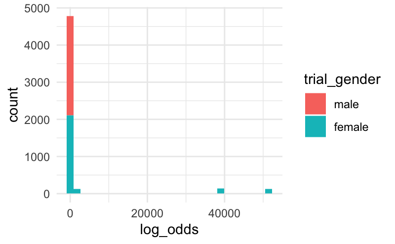

```r
final_prod %>%
  group_by(log_odds,trial_gender,lexeme) %>%
  unique() %>%
  ggplot(aes(x=log_odds,fill=trial_gender))+
  geom_histogram()
```

[output not shown]

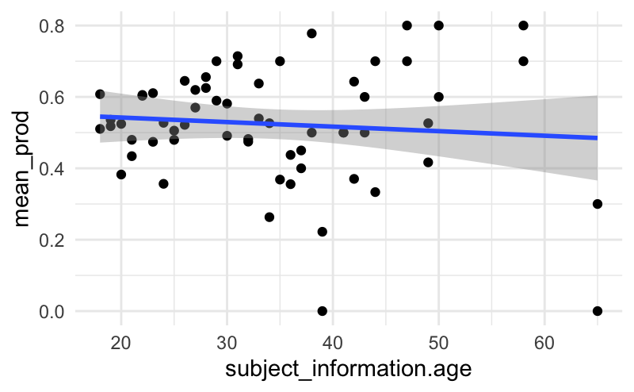

```r
final_prod %>%
  group_by(trial_gender,subject_information.age) %>%
  summarise(mean_prod = mean(response_neutral)) %>%
  ggplot(aes(x=subject_information.age,y=mean_prod)) +
  geom_point() +
  geom_smooth(method="lm")
```

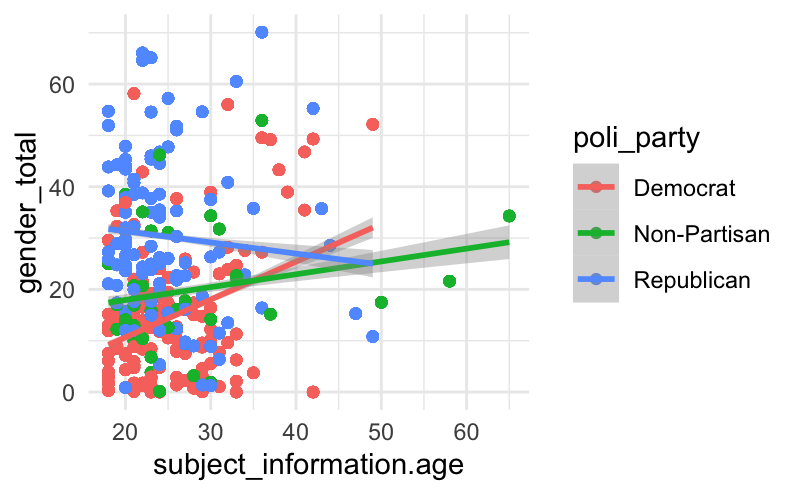

```r
final_prod %>%
  ggplot(aes(x=subject_information.age,y=gender_total,color=poli_party)) +
  geom_point() +
  geom_smooth(method="lm")
```

[output not shown]

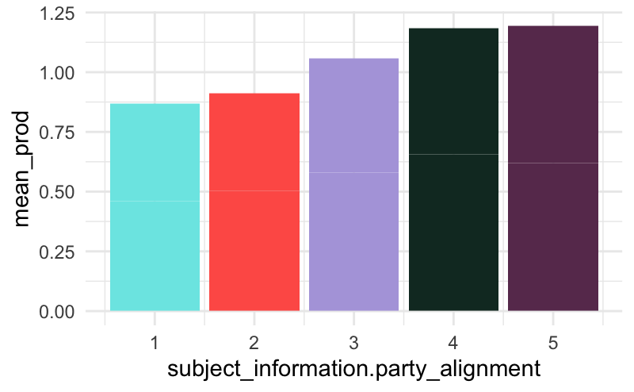

```r
final_prod %>%
  group_by(trial_gender,subject_information.party_alignment) %>%
  summarise(mean_prod = mean(response_neutral)) %>%
  ggplot(aes(x=subject_information.party_alignment,y=mean_prod,fill=as.factor(subject_information.party_alignment))) +
  geom_bar(stat="identity") +
  scale_fill_manual(values = bran_palette) +
    theme(legend.position = "none")
```

[output not shown]

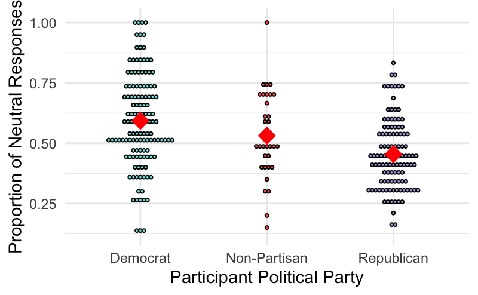

```r
final_prod %>%
  group_by(workerid,poli_party) %>%
  summarize(mean_prod = mean(response_neutral)) %>%
  ggplot(aes(x=poli_party,y=mean_prod,fill=poli_party)) +
  geom_dotplot(binaxis = "y",stackdir = "center",dotsize = 0.5) +
  stat_summary(fun.y=mean, geom="point", shape=18,
                 size=5, color="red") +
  theme(legend.position = "none") +
  scale_fill_manual(values=bran_palette) +
  scale_x_discrete(limits=c("Democrat","Non-Partisan","Republican")) +
  labs(x="Participant Political Party",y="Proportion of Neutral Responses")
```

```r
ggsave("prod-dot-party.png", width=7,height=5,path='/Users/branpap/Desktop/gender_ideology/talks_and_papers/qp_paper/figures')
```

[output not shown]

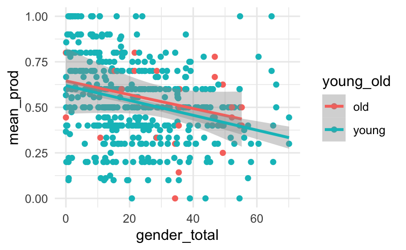

```r
final_prod %>%
  group_by(trial_gender,gender_total,young_old) %>%
  summarise(mean_prod = mean(response_neutral)) %>%
  ggplot(aes(x=gender_total,y=mean_prod,color=young_old)) +
  geom_point() +
  geom_smooth(method="lm")
```

## 3.1 Production Proportion Results

prod_all %>% mutate(response_gender = case_when( response_gender == “male/neutral” ~ “neutral”, TRUE ~ response_gender )) %>% ggplot() + geom_mosaic(aes(x=product(subject_information.party_alignment), fill=response_gender)) + scale_fill_manual(values=bran_palette) + labs(x=“Political Alignment”,y=“Response Gender Proportions”, fill=“Response Gender”, title=“Proportion of Response Genders by Gender Seen (facet) and political alignment”) + facet_wrap(~gender)

```r
test <- prod_all %>%
  mutate(response_gender = case_when(
    response_gender == "male/neutral" ~ "neutral",
    TRUE ~ response_gender
  )) %>%
  select(workerid,gender,response_gender,subject_information.party_alignment) %>%
  rename(trial_gender = gender) %>%
  mutate(trial_gender = as.factor(trial_gender),
         response_gender = as.factor(response_gender))
```

```r
test_d <- test %>%
  mutate(id = as.factor(row_number())) %>%
  expand_grid(c("male","female","neutral"),test$id) %>%
  rename(response_old = response_gender)
```

```r
colnames(test_d)[6] <- "response_gender"
```

```r
test_d <- test_d %>%
  group_by(id) %>%
  mutate(response = case_when(response_gender == response_old ~ 1,TRUE ~ 0)) %>%
  select(-response_old)
```

```r
dodge = position_dodge(0.9)
```

```r
blah <- test_d %>%
  group_by(response_gender,trial_gender,subject_information.party_alignment) %>%
  summarise(participants = n_distinct(workerid))
```

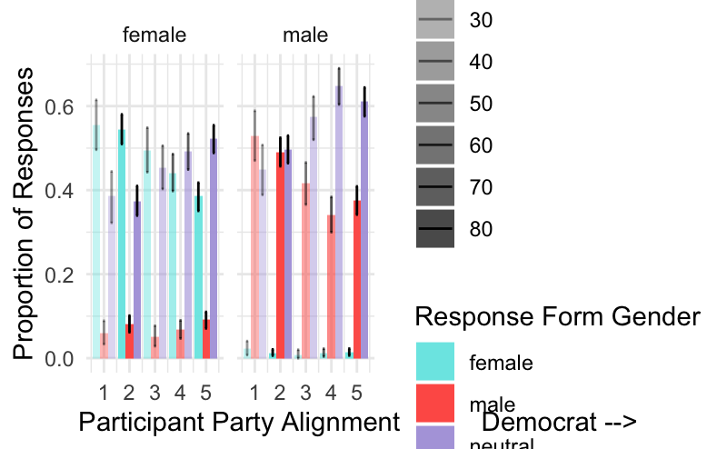

```r
test_d %>%
  group_by(response_gender,trial_gender,subject_information.party_alignment) %>%
  summarize(proportion = mean(response),
            CI.Low = ci.low(response),
            CI.High = ci.high(response),
            obs = n(),
            participants = n_distinct(workerid)) %>%
  rename(party_alignment = subject_information.party_alignment) %>%
  ungroup() %>%
  mutate(YMin = proportion - CI.Low,
         YMax = proportion + CI.High) %>%
  ggplot(aes(x=party_alignment,
             y=proportion,
             fill=response_gender,
             alpha = participants)) +
  geom_bar(stat="identity",
           position = dodge) +
  geom_errorbar(aes(ymin = YMin, ymax=YMax),
                position = dodge,
                width=0.25) +
  facet_wrap(~trial_gender) +
  scale_fill_manual(values = bran_palette) +
  scale_alpha(range=c(0.4,1)) +
  labs(y="Proportion of Responses",x="<-- Republican           Participant Party Alignment           Democrat -->", fill="Response Form Gender", alpha="# of Participants")
```

## 3.2 Same but by ideology

```r
test_2 <- prod_all %>%
  mutate(response_gender = case_when(
    response_gender == "male/neutral" ~ "neutral",
    TRUE ~ response_gender
  )) %>%
  select(workerid,gender,response_gender,gender_total,poli_party) %>%
  mutate(ideology = cut_number(gender_total,n=3,labels=c("progressive","moderate","conservative"))) %>%
  rename(trial_gender = gender) %>%
  mutate(trial_gender = as.factor(trial_gender),
         response_gender = as.factor(response_gender))
```

```r
test_e <- test_2 %>%
  mutate(id = as.factor(row_number())) %>%
  expand_grid(c("male","female","neutral"),test$id) %>%
  rename(response_old = response_gender)
```

```r
colnames(test_e)[8] <- "response_gender"
```

```r
test_e <- test_e %>%
  group_by(id) %>%
  mutate(response = case_when(response_gender == response_old ~ 1,TRUE ~ 0)) %>%
  select(-response_old)
```

```r
blah2<- test_e %>%
  group_by(response_gender,trial_gender,ideology,poli_party) %>%
  summarise(participants = n_distinct(workerid))
```

[figure not shown]

```r
test_e %>%
  group_by(response_gender,trial_gender,ideology,poli_party) %>%
  summarize(proportion = mean(response),
            CI.Low = ci.low(response),
            CI.High = ci.high(response),
            obs = n(),
            participants = n_distinct(workerid)) %>%
  ungroup() %>%
  mutate(YMin = proportion - CI.Low,
         YMax = proportion + CI.High) %>%
  ggplot(aes(x=ideology,
             y=proportion,
             fill=response_gender,
             alpha=as.numeric(participants))) +
  geom_bar(stat="identity",
           position = dodge) +
  geom_errorbar(aes(ymin = YMin, ymax=YMax),
                position = dodge,
                width=0.25) +
  facet_grid(poli_party~trial_gender) +
  scale_fill_manual(values = sec_palette, limits=c("male","female","neutral")) +
  scale_alpha(range=c(0.4,1)) +
  labs(y="Proportion of Responses",x="Gender Ideology", fill="Response Form Gender",alpha = "# of Participants") +
  theme(text=element_text(size=14)) +
  theme(axis.text.x = element_text(angle=20, vjust=.8)) +
  theme(legend.position = "top", legend.text = element_text(size=10), legend.title = element_text(size=10))
```

```r
# +
#  scale_x_discrete(sec.axis = sec_axis(~ . , name = "Gender Seen", breaks = NULL))
```

```r
ggsave("prod-3x2x3.png", width=7,height=5,path='/Users/branpap/Desktop/gender_ideology/talks_and_papers/qp_paper/figures')
```

[output not shown]

```r
flight_attendant <- prod_all %>%
  filter(lexeme == "flight attendant") %>%
  mutate(response_gender = case_when(
    response_gender == "male/neutral" ~ "neutral",
    TRUE ~ response_gender
  )) %>%
  select(workerid,gender,response_gender,gender_total,poli_party) %>%
  mutate(ideology = cut_number(gender_total,n=3,labels=c("progressive","moderate","conservative"))) %>%
  rename(trial_gender = gender) %>%
  mutate(trial_gender = as.factor(trial_gender),
         response_gender = as.factor(response_gender))
```

```r
flight_attendant <- flight_attendant %>%
  mutate(id = as.factor(row_number())) %>%
  expand_grid(c("male","female","neutral"),test$id) %>%
  rename(response_old = response_gender)
```

```r
colnames(flight_attendant)[8] <- "response_gender"
```

```r
flight_attendant <- flight_attendant %>%
  group_by(id) %>%
  mutate(response = case_when(response_gender == response_old ~ 1,TRUE ~ 0)) %>%
  select(-response_old)
```

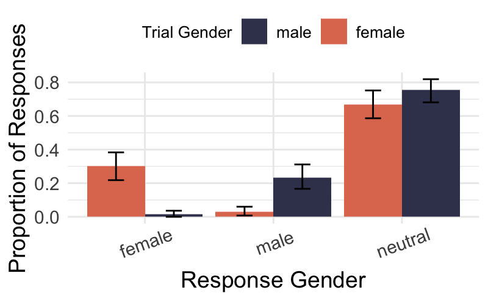

```r
flight_attendant %>%
  group_by(response_gender,trial_gender) %>%
  summarize(proportion = mean(response),
            CI.Low = ci.low(response),
            CI.High = ci.high(response),
            obs = n(),
            participants = n_distinct(workerid)) %>%
  ungroup() %>%
  mutate(YMin = proportion - CI.Low,
         YMax = proportion + CI.High) %>%
  ggplot(aes(x=response_gender,
             y=proportion,
             fill=trial_gender)) +
  geom_bar(stat="identity",
           position = dodge) +
  geom_errorbar(aes(ymin = YMin, ymax=YMax),
                position = dodge,
                width=0.25) +
  scale_fill_manual(values = sec_palette, limits=c("male","female")) +
  scale_alpha(range=c(0.4,1)) +
  labs(y="Proportion of Responses",x="Response Gender", fill="Trial Gender",alpha = "# of Participants") +
  theme(text=element_text(size=14)) +
  theme(axis.text.x = element_text(angle=20, vjust=.8)) +
  theme(legend.position = "top", legend.text = element_text(size=10), legend.title = element_text(size=10))
```

```r
# +
#  scale_x_discrete(sec.axis = sec_axis(~ . , name = "Gender Seen", breaks = NULL))
```

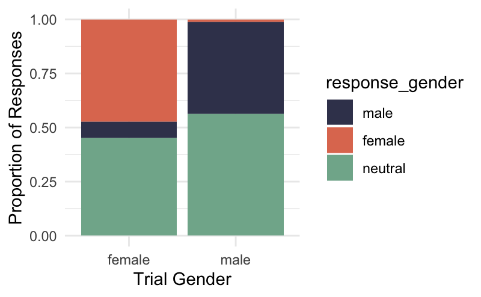

```r
prod_all %>%
  ggplot(aes(x=trial_gender,fill=response_gender)) +
  geom_bar(position="fill") +
  scale_fill_manual(values = sec_palette, limits=c("male","female","neutral")) +
  labs(x="Trial Gender", y = "Proportion of Responses", legend="Response Gender")
```

# 4 Incongruent Response Analysis (Auxiliary)

## 4.1 New Tests

```r
simple_ideology <- lmer(response_neutral~c_trial_gender*c_gender_total + (1|workerid) + (1|lexeme),data=final_prod)
```

```r
summary(simple_ideology)
```

```
Linear mixed model fit by REML. t-tests use Satterthwaite's method ['lmerModLmerTest']
Formula: response_neutral ~ c_trial_gender * c_gender_total + (1 | workerid) +
    (1 | lexeme)
   Data: final_prod

REML criterion at convergence: 6058

Scaled residuals:
    Min      1Q  Median      3Q     Max
-2.4697 -0.8078  0.0840  0.7969  2.4395

Random effects:
 Groups   Name        Variance Std.Dev.
 workerid (Intercept) 0.02106  0.1451
 lexeme   (Intercept) 0.05248  0.2291
 Residual             0.17310  0.4161
Number of obs: 5179, groups:  workerid, 271; lexeme, 20

Fixed effects:
                                Estimate Std. Error         df t value Pr(>|t|)
(Intercept)                    5.202e-01  5.230e-02  2.012e+01   9.947 3.26e-09 ***
c_trial_gender                 1.030e-01  1.161e-02  4.905e+03   8.865  < 2e-16 ***
c_gender_total                -3.962e-03  6.698e-04  2.717e+02  -5.915 9.94e-09 ***
c_trial_gender:c_gender_total -4.559e-04  7.402e-04  4.906e+03  -0.616    0.538
---
Signif. codes:  0 ‘***’ 0.001 ‘**’ 0.01 ‘*’ 0.05 ‘.’ 0.1 ‘ ’ 1

Correlation of Fixed Effects:
            (Intr) c_trl_ c_gnd_
c_tril_gndr -0.004
c_gendr_ttl  0.001 -0.003
c_trl_gn:__ -0.001  0.014 -0.022
```

```r
simple_political <- lmer(response_neutral~c_trial_gender*poli_party + (1|workerid) + (1|lexeme),data=final_prod)
```

```r
summary(simple_political)
```

```
Linear mixed model fit by REML. t-tests use Satterthwaite's method ['lmerModLmerTest']
Formula: response_neutral ~ c_trial_gender * poli_party + (1 | workerid) +
    (1 | lexeme)
   Data: final_prod

REML criterion at convergence: 6049.4

Scaled residuals:
     Min       1Q   Median       3Q      Max
-2.47590 -0.80379  0.08785  0.79611  2.41957

Random effects:
 Groups   Name        Variance Std.Dev.
 workerid (Intercept) 0.02062  0.1436
 lexeme   (Intercept) 0.05256  0.2293
 Residual             0.17315  0.4161
Number of obs: 5179, groups:  workerid, 271; lexeme, 20

Fixed effects:
                                        Estimate Std. Error         df t value Pr(>|t|)
(Intercept)                              0.58534    0.05349   21.93086  10.944 2.37e-10
c_trial_gender                           0.09270    0.01692 4905.63445   5.478 4.51e-08
poli_partyNon-Partisan                  -0.06160    0.03282  266.81294  -1.877   0.0617
poli_partyRepublican                    -0.14271    0.02254  269.18107  -6.332 1.01e-09
c_trial_gender:poli_partyNon-Partisan    0.01450    0.03623 4895.73962   0.400   0.6891
c_trial_gender:poli_partyRepublican      0.02061    0.02501 4903.49828   0.824   0.4098

(Intercept)                           ***
c_trial_gender                        ***
poli_partyNon-Partisan                .
poli_partyRepublican                  ***
c_trial_gender:poli_partyNon-Partisan
c_trial_gender:poli_partyRepublican
---
Signif. codes:  0 ‘***’ 0.001 ‘**’ 0.01 ‘*’ 0.05 ‘.’ 0.1 ‘ ’ 1

Correlation of Fixed Effects:
            (Intr) c_trl_ pl_N-P pl_prR c__:_N
c_tril_gndr -0.006
pl_prtyNn-P -0.133  0.010
pl_prtyRpbl -0.193  0.015  0.314
c_trl_:_N-P  0.003 -0.467 -0.015 -0.007
c_trl_gn:_R  0.004 -0.676 -0.007 -0.020  0.316
```

```r
simple_social <- lmer(response_neutral~c_trial_gender*poli_party + c_trial_gender:c_gender_total + c_gender_total + (1|workerid) + (1|lexeme),data=final_prod)
```

```r
summary(simple_social)
```

```
Linear mixed model fit by REML. t-tests use Satterthwaite's method ['lmerModLmerTest']
Formula: response_neutral ~ c_trial_gender * poli_party + c_trial_gender:c_gender_total +
    c_gender_total + (1 | workerid) + (1 | lexeme)
   Data: final_prod

REML criterion at convergence: 6060.6

Scaled residuals:
     Min       1Q   Median       3Q      Max
-2.46891 -0.79930  0.08565  0.80170  2.44193

Random effects:
 Groups   Name        Variance Std.Dev.
 workerid (Intercept) 0.01941  0.1393
 lexeme   (Intercept) 0.05250  0.2291
 Residual             0.17313  0.4161
Number of obs: 5179, groups:  workerid, 271; lexeme, 20

Fixed effects:
                                        Estimate Std. Error         df t value Pr(>|t|)
(Intercept)                            5.679e-01  5.360e-02  2.217e+01  10.595 3.83e-10
c_trial_gender                         8.624e-02  1.796e-02  4.914e+03   4.802 1.62e-06
poli_partyNon-Partisan                -4.874e-02  3.236e-02  2.665e+02  -1.506 0.133129
poli_partyRepublican                  -1.035e-01  2.476e-02  2.724e+02  -4.180 3.93e-05
c_gender_total                        -2.578e-03  7.312e-04  2.732e+02  -3.525 0.000496
c_trial_gender:poli_partyNon-Partisan  1.926e-02  3.651e-02  4.897e+03   0.528 0.597781
c_trial_gender:poli_partyRepublican    3.512e-02  2.826e-02  4.914e+03   1.243 0.214051
c_trial_gender:c_gender_total         -9.583e-04  8.374e-04  4.914e+03  -1.144 0.252549

(Intercept)                           ***
c_trial_gender                        ***
poli_partyNon-Partisan
poli_partyRepublican                  ***
c_gender_total                        ***
c_trial_gender:poli_partyNon-Partisan
c_trial_gender:poli_partyRepublican
c_trial_gender:c_gender_total
---
Signif. codes:  0 ‘***’ 0.001 ‘**’ 0.01 ‘*’ 0.05 ‘.’ 0.1 ‘ ’ 1

Correlation of Fixed Effects:
            (Intr) c_trl_ pl_N-P pl_prR c_gnd_ c__:_N c__:_R
c_tril_gndr -0.008
pl_prtyNn-P -0.139  0.013
pl_prtyRpbl -0.210  0.023  0.330
c_gendr_ttl  0.093 -0.018 -0.114 -0.453
c_trl_:_N-P  0.004 -0.478 -0.016 -0.010  0.007
c_trl_gn:_R  0.007 -0.720 -0.010 -0.029  0.021  0.335
c_trl_gn:__ -0.005  0.335  0.007  0.021 -0.031 -0.123 -0.466
```

```r
reps_only <- final_prod %>%
  filter(poli_party == "Republican")

dems_only <- final_prod %>%
  filter(poli_party == "Democrat")

ind_only <- final_prod %>%
  filter(poli_party == "Non-Partisan")
```

```r
rep_model <- lmer(response_neutral~c_trial_gender*c_gender_total + c_log_odds:c_age + c_log_odds + (1+ c_trial_gender|workerid) + (1 + c_trial_gender|lexeme),data=reps_only)
```

```r
summary(rep_model)
```

```
Linear mixed model fit by REML. t-tests use Satterthwaite's method ['lmerModLmerTest']
Formula: response_neutral ~ c_trial_gender * c_gender_total + c_log_odds:c_age +
    c_log_odds + (1 + c_trial_gender | workerid) + (1 + c_trial_gender |      lexeme)
   Data: reps_only

REML criterion at convergence: 1859.5

Scaled residuals:
     Min       1Q   Median       3Q      Max
-2.77436 -0.55181 -0.08588  0.50309  2.83989

Random effects:
 Groups   Name           Variance Std.Dev. Corr
 workerid (Intercept)    0.010895 0.10438
          c_trial_gender 0.009945 0.09972  -0.84
 lexeme   (Intercept)    0.050303 0.22428
          c_trial_gender 0.199443 0.44659  0.55
 Residual                0.121912 0.34916
Number of obs: 2062, groups:  workerid, 108; lexeme, 20

Fixed effects:
                                Estimate Std. Error         df t value Pr(>|t|)
(Intercept)                    4.423e-01  5.222e-02  2.104e+01   8.470 3.21e-08 ***
c_trial_gender                 1.700e-01  1.034e-01  2.034e+01   1.644  0.11560
c_gender_total                 4.768e-04  8.286e-04  1.062e+02   0.575  0.56627
c_log_odds                     1.209e-05  3.565e-06  1.804e+01   3.391  0.00324 **
c_trial_gender:c_gender_total -1.350e-03  1.194e-03  1.073e+02  -1.131  0.26053
c_log_odds:c_age              -9.958e-09  1.211e-07  1.930e+03  -0.082  0.93449
---
Signif. codes:  0 ‘***’ 0.001 ‘**’ 0.01 ‘*’ 0.05 ‘.’ 0.1 ‘ ’ 1

Correlation of Fixed Effects:
            (Intr) c_trl_ c_gnd_ c_lg_d c__:__
c_tril_gndr  0.485
c_gendr_ttl -0.135  0.037
c_log_odds   0.000  0.163  0.002
c_trl_gn:__  0.051 -0.099 -0.374 -0.003
c_lg_dds:c_ -0.002  0.002  0.007  0.018 -0.029
fit warnings:
Some predictor variables are on very different scales: consider rescaling
```

```r
dem_model <- lmer(response_neutral~c_trial_gender*c_gender_total + c_log_odds:c_age + c_log_odds + (1+ c_trial_gender|workerid) + (1 + c_trial_gender|lexeme),data=dems_only)
```

```r
summary(dem_model)
```

```
Linear mixed model fit by REML. t-tests use Satterthwaite's method ['lmerModLmerTest']
Formula: response_neutral ~ c_trial_gender * c_gender_total + c_log_odds:c_age +
    c_log_odds + (1 + c_trial_gender | workerid) + (1 + c_trial_gender |      lexeme)
   Data: dems_only

REML criterion at convergence: 2347.9

Scaled residuals:
     Min       1Q   Median       3Q      Max
-2.75166 -0.67859  0.04751  0.68489  2.74682

Random effects:
 Groups   Name           Variance Std.Dev. Corr
 workerid (Intercept)    0.02295  0.1515
          c_trial_gender 0.01539  0.1240   -0.36
 lexeme   (Intercept)    0.03322  0.1823
          c_trial_gender 0.16870  0.4107   0.30
 Residual                0.12702  0.3564
Number of obs: 2438, groups:  workerid, 128; lexeme, 20

Fixed effects:
                                Estimate Std. Error         df t value Pr(>|t|)
(Intercept)                    5.563e-01  4.420e-02  2.417e+01  12.587 4.19e-12 ***
c_trial_gender                 1.181e-01  9.582e-02  2.058e+01   1.233   0.2315
c_gender_total                -5.045e-03  1.140e-03  1.313e+02  -4.424 2.01e-05 ***
c_log_odds                     1.014e-05  3.782e-06  1.794e+01   2.682   0.0152 *
c_trial_gender:c_gender_total -8.479e-04  1.386e-03  1.348e+02  -0.612   0.5417
c_log_odds:c_age              -7.587e-08  1.359e-07  2.300e+03  -0.558   0.5766
---
Signif. codes:  0 ‘***’ 0.001 ‘**’ 0.01 ‘*’ 0.05 ‘.’ 0.1 ‘ ’ 1

Correlation of Fixed Effects:
            (Intr) c_trl_ c_gnd_ c_lg_d c__:__
c_tril_gndr  0.251
c_gendr_ttl  0.176 -0.023
c_log_odds   0.001  0.186  0.001
c_trl_gn:__ -0.041  0.102 -0.215  0.000
c_lg_dds:c_  0.006  0.005  0.014  0.015  0.056
fit warnings:
Some predictor variables are on very different scales: consider rescaling
```

### 4.1.1 Comments

[^1]: It is my hope and intention that this color palette be color-blind friendly. If you have accessibility concerns, please do not hesitate to reach out to me!
[^2]: https://www.english-corpora.org/coca/
[^3]: https://adfontesmedia.com